# Lesson 4

### Scatterplots

Notes:

```r
library(ggplot2)
pf <- read.csv('pseudo_facebook.tsv', sep='\t')

qplot(x=age, y=friend_count, data=pf)
```

```r
### alternate way

qplot(age,friend_count, data=pf)
```

#### What are some things that you notice right away?

Response:

### ggplot Syntax

Notes: The main difference between ggplot and qplot is: ggplot needs to specify which geom and ggplot use aes wrap, ggplot come plot more complex plot use + to add one new layer its better to add one layer at one time

```r
ggplot(aes(x=age, y=friend_count), data=pf) + geom_point()
```

```r
summary(pf$age)
```

```
##    Min. 1st Qu.  Median    Mean 3rd Qu.    Max.
##   13.00   20.00   28.00   37.28   50.00  113.00
```

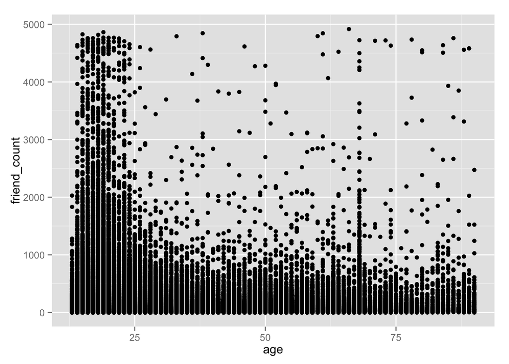

```r
ggplot(aes(x=age, y=friend_count), data=pf) + geom_point() + xlim(13,90)
```

### Overplotting

Notes: set the transport using alpha param, alpha=1/20 means use 1 point to express 20 points at the same location

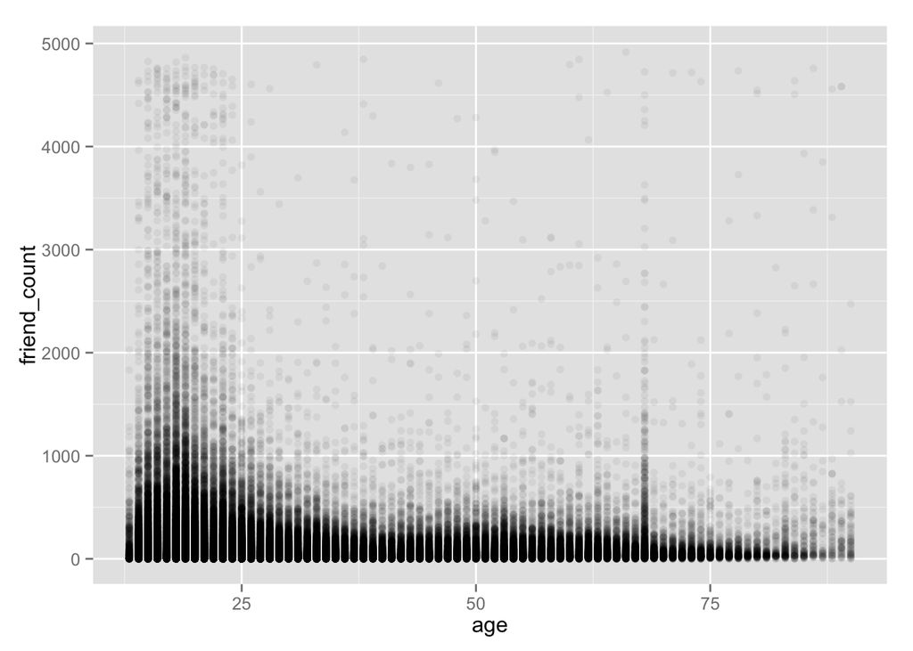

```r
ggplot(aes(x=age, y=friend_count), data=pf) +
  geom_point(alpha=1/20) +
  xlim(13,90)
```

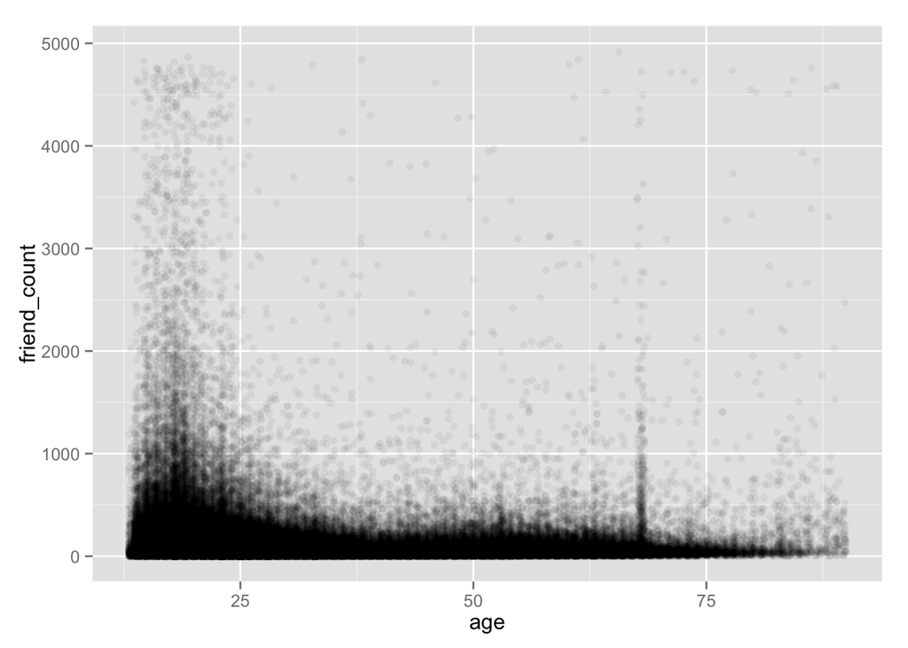

```r
ggplot(aes(x=age, y=friend_count), data=pf) +
  geom_jitter(alpha=1/20) +
  xlim(13,90)
```

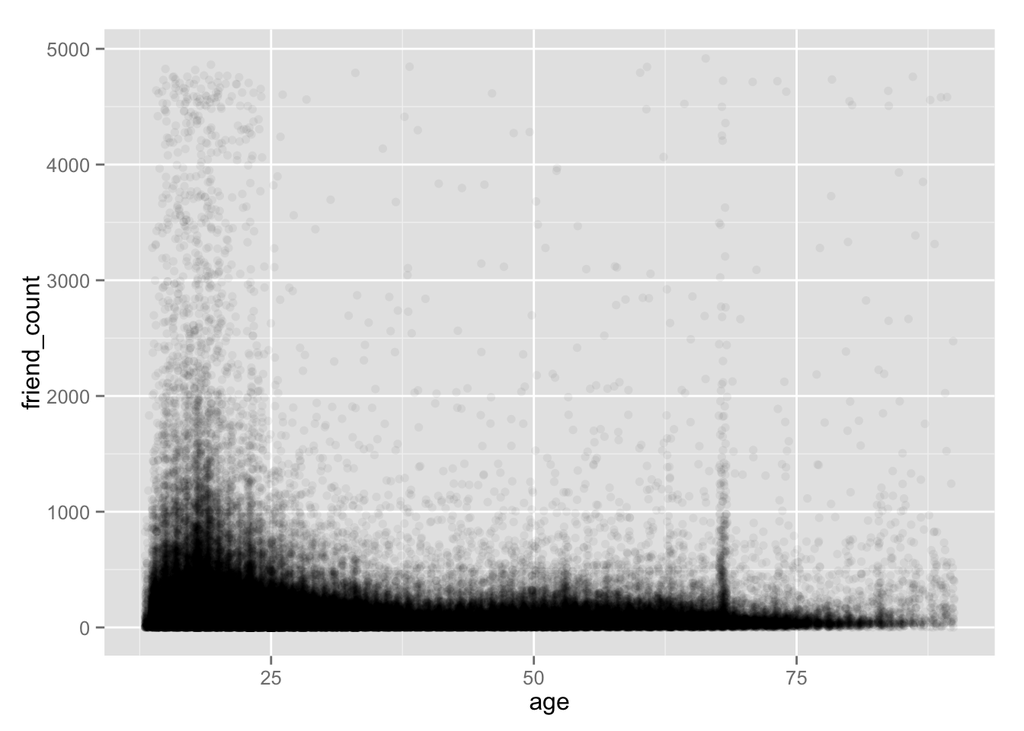

```r
ggplot(aes(x=age, y=friend_count), data=pf) +
  geom_jitter(alpha=0.05) +
  xlim(13,90)
```

#### What do you notice in the plot?

Response:

### Coord_trans()

Notes:

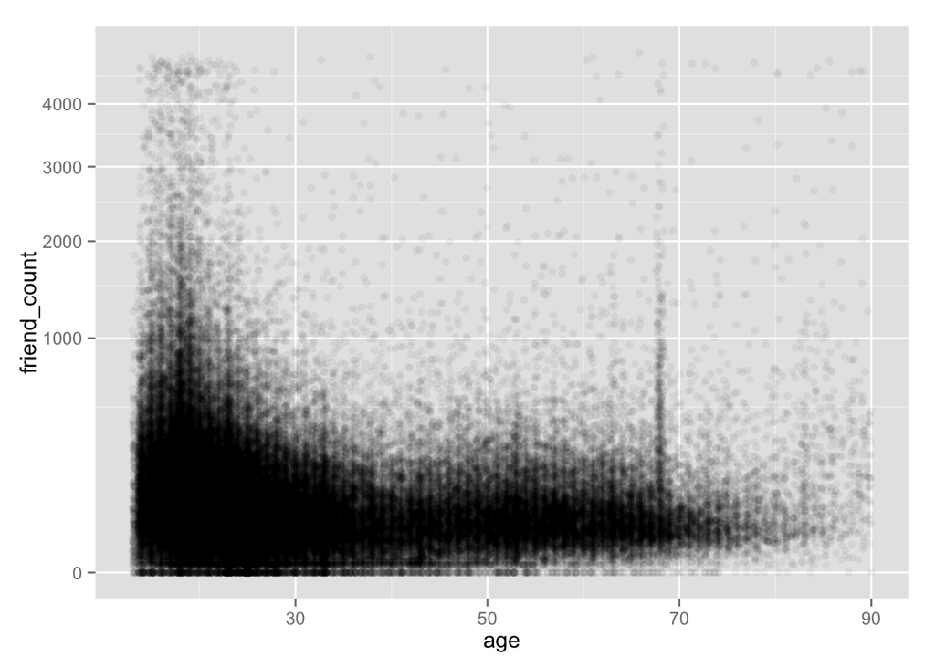

```r
ggplot(aes(x=age, y=friend_count), data=pf) +
  geom_point(alpha=0.05, position = position_jitter(h=0)) +
  xlim(13,90) +
  coord_trans( y="sqrt")
```

#### Look up the documentation for coord_trans() and add a layer to the plot that transforms friend_count using the square root function. Create your plot!

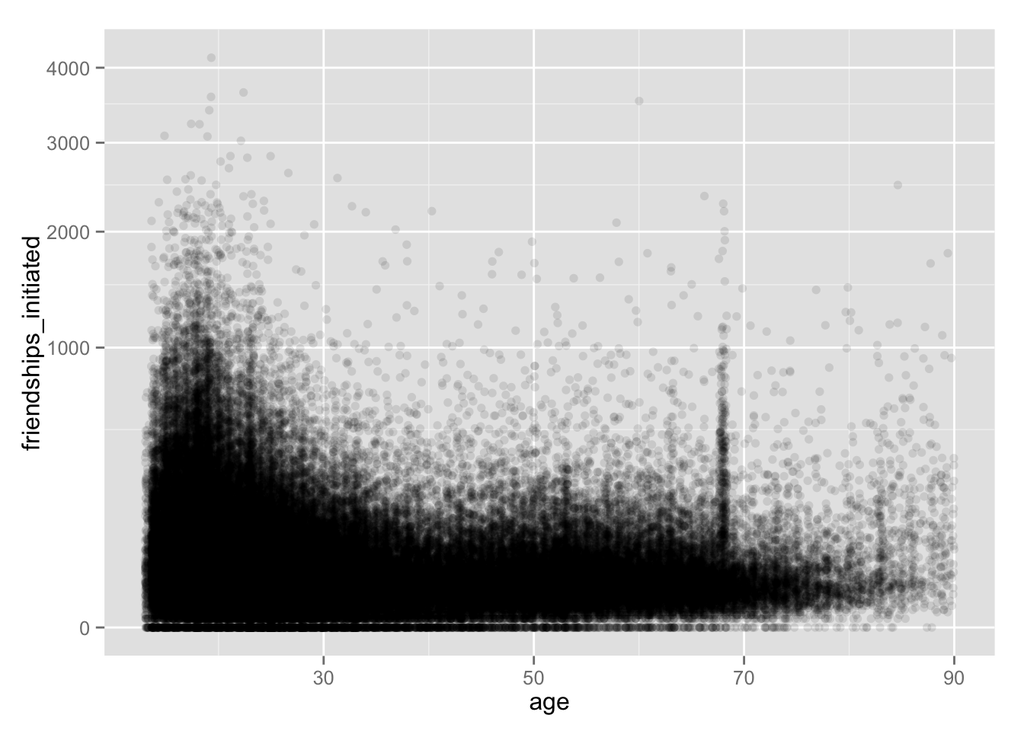

```r
ggplot(aes(x=age, y=friendships_initiated), data=pf) +
  geom_point(alpha=1/10, position=position_jitter(h=0)) +
  xlim(13,90) +
  coord_trans(y="sqrt")
```